# BIS 15L Midterm 2

```r
library(tidyverse)
library(janitor)
library(here)
library(naniar)
```

## Instructions

Answer the following questions and complete the exercises in RMarkdown. Please embed all of your code and push your final work to your repository. Your code should be organized, clean, and run free from errors. Be sure to **add your name** to the author header above. You may use any resources to answer these questions (including each other), but you may not post questions to Open Stacks or external help sites. There are 10 total questions.

Make sure to use the formatting conventions of RMarkdown to make your report neat and clean! Your plots should use consistent aesthetics throughout.

This exam is due by **12:00p on Tuesday, February 22**.

## Gapminder

For this assignment, we are going to use data from [gapminder](https://www.gapminder.org/). Gapminder includes information about economics, population, social issues, and life expectancy from countries all over the world. We will use three data sets, so please load all three as separate objects.

1. population_total.csv
2. income_per_person_gdppercapita_ppp_inflation_adjusted.csv
3. life_expectancy_years.csv

```r
population<-readr::read_csv("data/population_total.csv")
income_gdp<-readr::read_csv("data/income_per_person_gdppercapita_ppp_inflation_adjusted.csv")
life_exp<-readr::read_csv("data/life_expectancy_years.csv")
summary(population)
```

[output not shown]

[output cut: 624 more lines]

[output not shown]

```r
names(population)
```

```
##   [1] "country" "1800"    "1801"    "1802"    "1803"    "1804"    "1805"
##   [8] "1806"    "1807"    "1808"    "1809"    "1810"    "1811"    "1812"
##  [15] "1813"    "1814"    "1815"    "1816"    "1817"    "1818"    "1819"
##  [22] "1820"    "1821"    "1822"    "1823"    "1824"    "1825"    "1826"
##  [29] "1827"    "1828"    "1829"    "1830"    "1831"    "1832"    "1833"
##  [36] "1834"    "1835"    "1836"    "1837"    "1838"    "1839"    "1840"
##  [43] "1841"    "1842"    "1843"    "1844"    "1845"    "1846"    "1847"
##  [50] "1848"    "1849"    "1850"    "1851"    "1852"    "1853"    "1854"
##  [57] "1855"    "1856"    "1857"    "1858"    "1859"    "1860"    "1861"
##  [64] "1862"    "1863"    "1864"    "1865"    "1866"    "1867"    "1868"
##  [71] "1869"    "1870"    "1871"    "1872"    "1873"    "1874"    "1875"
##  [78] "1876"    "1877"    "1878"    "1879"    "1880"    "1881"    "1882"
##  [85] "1883"    "1884"    "1885"    "1886"    "1887"    "1888"    "1889"
##  [92] "1890"    "1891"    "1892"    "1893"    "1894"    "1895"    "1896"
##  [99] "1897"    "1898"    "1899"    "1900"    "1901"    "1902"    "1903"
```

[output cut: 29 more lines]

```r
head(life_exp)
```

```
## # A tibble: 6 x 302
##   country  `1800` `1801` `1802` `1803` `1804` `1805` `1806` `1807` `1808` `1809`
##   <chr>     <dbl>  <dbl>  <dbl>  <dbl>  <dbl>  <dbl>  <dbl>  <dbl>  <dbl>  <dbl>
## 1 Afghani~   28.2   28.2   28.2   28.2   28.2   28.2   28.1   28.1   28.1   28.1
## 2 Albania    35.4   35.4   35.4   35.4   35.4   35.4   35.4   35.4   35.4   35.4
## 3 Algeria    28.8   28.8   28.8   28.8   28.8   28.8   28.8   28.8   28.8   28.8
## 4 Andorra    NA     NA     NA     NA     NA     NA     NA     NA     NA     NA
## 5 Angola     27     27     27     27     27     27     27     27     27     27
## 6 Antigua~   33.5   33.5   33.5   33.5   33.5   33.5   33.5   33.5   33.5   33.5
## # ... with 291 more variables: `1810` <dbl>, `1811` <dbl>, `1812` <dbl>,
## #   `1813` <dbl>, `1814` <dbl>, `1815` <dbl>, `1816` <dbl>, `1817` <dbl>,
## #   `1818` <dbl>, `1819` <dbl>, `1820` <dbl>, `1821` <dbl>, `1822` <dbl>,
## #   `1823` <dbl>, `1824` <dbl>, `1825` <dbl>, `1826` <dbl>, `1827` <dbl>,
## #   `1828` <dbl>, `1829` <dbl>, `1830` <dbl>, `1831` <dbl>, `1832` <dbl>,
## #   `1833` <dbl>, `1834` <dbl>, `1835` <dbl>, `1836` <dbl>, `1837` <dbl>,
## #   `1838` <dbl>, `1839` <dbl>, `1840` <dbl>, `1841` <dbl>, `1842` <dbl>, ...
```

```r
head(income_gdp)
```

```
## # A tibble: 6 x 242
##   country  `1800` `1801` `1802` `1803` `1804` `1805` `1806` `1807` `1808` `1809`
##   <chr>     <dbl>  <dbl>  <dbl>  <dbl>  <dbl>  <dbl>  <dbl>  <dbl>  <dbl>  <dbl>
## 1 Afghani~    603    603    603    603    603    603    603    603    603    603
## 2 Albania     667    667    667    667    667    668    668    668    668    668
## 3 Algeria     715    716    717    718    719    720    721    722    723    724
## 4 Andorra    1200   1200   1200   1200   1210   1210   1210   1210   1220   1220
## 5 Angola      618    620    623    626    628    631    634    637    640    642
## 6 Antigua~    757    757    757    757    757    757    757    758    758    758
## # ... with 231 more variables: `1810` <dbl>, `1811` <dbl>, `1812` <dbl>,
## #   `1813` <dbl>, `1814` <dbl>, `1815` <dbl>, `1816` <dbl>, `1817` <dbl>,
## #   `1818` <dbl>, `1819` <dbl>, `1820` <dbl>, `1821` <dbl>, `1822` <dbl>,
## #   `1823` <dbl>, `1824` <dbl>, `1825` <dbl>, `1826` <dbl>, `1827` <dbl>,
## #   `1828` <dbl>, `1829` <dbl>, `1830` <dbl>, `1831` <dbl>, `1832` <dbl>,
## #   `1833` <dbl>, `1834` <dbl>, `1835` <dbl>, `1836` <dbl>, `1837` <dbl>,
## #   `1838` <dbl>, `1839` <dbl>, `1840` <dbl>, `1841` <dbl>, `1842` <dbl>, ...
```

1. (3 points) Once you have an idea of the structure of the data, please make each data set tidy (hint: think back to pivots) and store them as new objects. You will need both the original (wide) and tidy (long) data!

```r
pop_long<-population%>%
  pivot_longer(-country,
               names_to = "year",
               values_to = "pop")
pop_long
```

```
## # A tibble: 58,695 x 3
##    country     year      pop
##    <chr>       <chr>   <dbl>
##  1 Afghanistan 1800  3280000
##  2 Afghanistan 1801  3280000
##  3 Afghanistan 1802  3280000
##  4 Afghanistan 1803  3280000
##  5 Afghanistan 1804  3280000
##  6 Afghanistan 1805  3280000
##  7 Afghanistan 1806  3280000
##  8 Afghanistan 1807  3280000
##  9 Afghanistan 1808  3280000
## 10 Afghanistan 1809  3280000
## # ... with 58,685 more rows
```

```r
life_long<-life_exp%>%
  pivot_longer(-country,
               names_to = "year",
               values_to = "life_exp")
life_long
```

```
## # A tibble: 56,287 x 3
##    country     year  life_exp
##    <chr>       <chr>    <dbl>
##  1 Afghanistan 1800      28.2
##  2 Afghanistan 1801      28.2
##  3 Afghanistan 1802      28.2
##  4 Afghanistan 1803      28.2
##  5 Afghanistan 1804      28.2
##  6 Afghanistan 1805      28.2
##  7 Afghanistan 1806      28.1
##  8 Afghanistan 1807      28.1
##  9 Afghanistan 1808      28.1
## 10 Afghanistan 1809      28.1
## # ... with 56,277 more rows
```

```r
income_long<-income_gdp%>%
  pivot_longer(-country,
               names_to = "year",
               values_to = "income_gdp")
income_long
```

```
## # A tibble: 46,513 x 3
##    country     year  income_gdp
##    <chr>       <chr>      <dbl>
##  1 Afghanistan 1800         603
##  2 Afghanistan 1801         603
##  3 Afghanistan 1802         603
##  4 Afghanistan 1803         603
##  5 Afghanistan 1804         603
##  6 Afghanistan 1805         603
##  7 Afghanistan 1806         603
##  8 Afghanistan 1807         603
##  9 Afghanistan 1808         603
## 10 Afghanistan 1809         603
## # ... with 46,503 more rows
```

2. (1 point) How many different countries are represented in the data? Provide the total number and their names. Since each data set includes different numbers of countries, you will need to do this for each one.

```r
population$country<-as.factor(population$country)
levels(population$country)
```

```
##   [1] "Afghanistan"                    "Albania"
##   [3] "Algeria"                        "Andorra"
##   [5] "Angola"                         "Antigua and Barbuda"
##   [7] "Argentina"                      "Armenia"
##   [9] "Australia"                      "Austria"
##  [11] "Azerbaijan"                     "Bahamas"
##  [13] "Bahrain"                        "Bangladesh"
##  [15] "Barbados"                       "Belarus"
##  [17] "Belgium"                        "Belize"
##  [19] "Benin"                          "Bhutan"
##  [21] "Bolivia"                        "Bosnia and Herzegovina"
##  [23] "Botswana"                       "Brazil"
##  [25] "Brunei"                         "Bulgaria"
##  [27] "Burkina Faso"                   "Burundi"
##  [29] "Cambodia"                       "Cameroon"
```

[output cut: 83 more lines]

```r
n_distinct(population$country)
```

```
## [1] 195
```

```r
life_exp$country<-as.factor(life_exp$country)
levels(life_exp$country)
```

```
##   [1] "Afghanistan"                    "Albania"
##   [3] "Algeria"                        "Andorra"
##   [5] "Angola"                         "Antigua and Barbuda"
##   [7] "Argentina"                      "Armenia"
##   [9] "Australia"                      "Austria"
##  [11] "Azerbaijan"                     "Bahamas"
##  [13] "Bahrain"                        "Bangladesh"
##  [15] "Barbados"                       "Belarus"
##  [17] "Belgium"                        "Belize"
##  [19] "Benin"                          "Bhutan"
##  [21] "Bolivia"                        "Bosnia and Herzegovina"
##  [23] "Botswana"                       "Brazil"
##  [25] "Brunei"                         "Bulgaria"
##  [27] "Burkina Faso"                   "Burundi"
##  [29] "Cambodia"                       "Cameroon"
```

[output cut: 79 more lines]

```r
n_distinct(life_exp$country)
```

```
## [1] 187
```

```r
income_gdp$country<-as.factor(income_gdp$country)
levels(income_gdp$country)
```

```
##   [1] "Afghanistan"                    "Albania"
##   [3] "Algeria"                        "Andorra"
##   [5] "Angola"                         "Antigua and Barbuda"
##   [7] "Argentina"                      "Armenia"
##   [9] "Australia"                      "Austria"
##  [11] "Azerbaijan"                     "Bahamas"
##  [13] "Bahrain"                        "Bangladesh"
##  [15] "Barbados"                       "Belarus"
##  [17] "Belgium"                        "Belize"
##  [19] "Benin"                          "Bhutan"
##  [21] "Bolivia"                        "Bosnia and Herzegovina"
##  [23] "Botswana"                       "Brazil"
##  [25] "Brunei"                         "Bulgaria"
##  [27] "Burkina Faso"                   "Burundi"
##  [29] "Cambodia"                       "Cameroon"
```

[output cut: 82 more lines]

```r
n_distinct(income_gdp$country)
```

```
## [1] 193
```

## Life Expectancy

3. (2 points) Let’s limit the data to 100 years (1920-2020). For these years, which country has the highest average life expectancy? How about the lowest average life expectancy?

#descending order

```r
life_long%>%
  filter(between(year,"1920","2020"))%>%
  group_by(country)%>%
  summarise(mean_life_exp=mean(life_exp))%>%
  arrange(desc(mean_life_exp))
```

```
## # A tibble: 187 x 2
##    country        mean_life_exp
##    <chr>                  <dbl>
##  1 Sweden                  73.5
##  2 Norway                  73.2
##  3 Netherlands             73.0
##  4 Iceland                 72.9
##  5 Australia               72.7
##  6 Switzerland             72.7
##  7 Denmark                 71.9
##  8 Canada                  71.8
##  9 New Zealand             71.4
## 10 United Kingdom          71.1
## # ... with 177 more rows
```

#ascending

```r
life_long%>%
  filter(between(year,"1920","2020"))%>%
  group_by(country)%>%
  summarise(mean_life_exp=mean(life_exp))%>%
  arrange(mean_life_exp)
```

```
## # A tibble: 187 x 2
##    country                  mean_life_exp
##    <chr>                            <dbl>
##  1 Central African Republic          41.8
##  2 Mali                              41.8
##  3 Ethiopia                          42.6
##  4 Sierra Leone                      42.6
##  5 Guinea-Bissau                     42.6
##  6 Burundi                           42.8
##  7 Malawi                            42.8
##  8 Uganda                            43.3
##  9 Eritrea                           43.4
## 10 Yemen                             43.6
## # ... with 177 more rows
```

4. (3 points) Although we can see which country has the highest life expectancy for the past 100 years, we don’t know which countries have changed the most. What are the top 5 countries that have experienced the biggest improvement in life expectancy between 1920-2020?

```r
life_long%>%
  filter(year=="1920"|year=="2020")%>%
  pivot_wider(names_from = year,
              names_prefix = "yr_",
              values_from = life_exp)%>%
  group_by(country)%>%
  mutate(gap_life_exp=yr_2020-yr_1920)%>%
  arrange(desc(gap_life_exp))%>%
  head(n=5)
```

```
## # A tibble: 5 x 4
## # Groups:   country [5]
##   country         yr_1920 yr_2020 gap_life_exp
##   <chr>             <dbl>   <dbl>        <dbl>
## 1 Kuwait             26.6    83.4         56.8
## 2 Kyrgyz Republic    16.6    73.1         56.5
## 3 Turkmenistan       15.2    70.5         55.3
## 4 South Korea        28.2    83.2         55
## 5 Tajikistan         16.7    71           54.3
```

5. (3 points) Make a plot that shows the change over the past 100 years for the country with the biggest improvement in life expectancy. Be sure to add appropriate aesthetics to make the plot clean and clear. Once you have made the plot, do a little internet searching and see if you can discover what historical event may have contributed to this remarkable change.  
   #An oil field was discovered in Kuwait in 1938. This would have brought great wealth to the country and would have contributed to the development of sanitation, health and medical care.

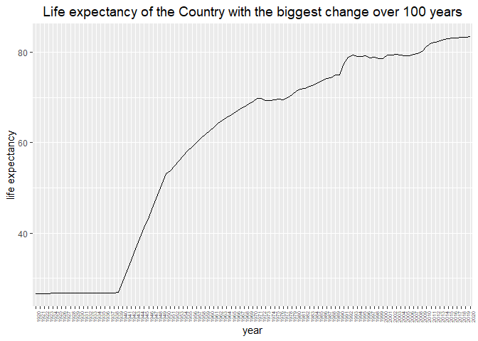

```r
life_exp%>%
  filter(country=="Kuwait")%>%
  pivot_longer(-country,
               names_to = "year",
               values_to = "life_exp")%>%
  filter(between(year,1920,2020))%>%
  ggplot(aes(x=year,y=life_exp,group=1))+
  geom_line()+
  labs(title = "Life expectancy of the Country with the biggest change over 100 years",
       x="year",
       y="life expectancy")+
  theme(plot.title = element_text(size = rel(1.3),hjust = 0.5))+
  theme(axis.text.x = element_text(size=5, angle = 90, hjust=1))
```

## Population Growth

6. (3 points) Which 5 countries have had the highest population growth over the past 100 years (1920-2020)?

```r
pop_long%>%
  filter(year=="1920"|year=="2020")%>%
  pivot_wider(names_from = year,
              names_prefix = "yr_",
              values_from = pop)%>%
  group_by(country)%>%
  mutate(gap_pop=yr_2020-yr_1920)%>%
  arrange(desc(gap_pop))%>%
  head(n=5)
```

```
## # A tibble: 5 x 4
## # Groups:   country [5]
##   country         yr_1920    yr_2020    gap_pop
##   <chr>             <dbl>      <dbl>      <dbl>
## 1 India         317000000 1380000000 1063000000
## 2 China         472000000 1440000000  968000000
## 3 Indonesia      47300000  274000000  226700000
## 4 United States 111000000  331000000  220000000
## 5 Pakistan       21700000  221000000  199300000
```

7. (4 points) Produce a plot that shows the 5 countries that have had the highest population growth over the past 100 years (1920-2020). Which countries appear to have had exponential growth?

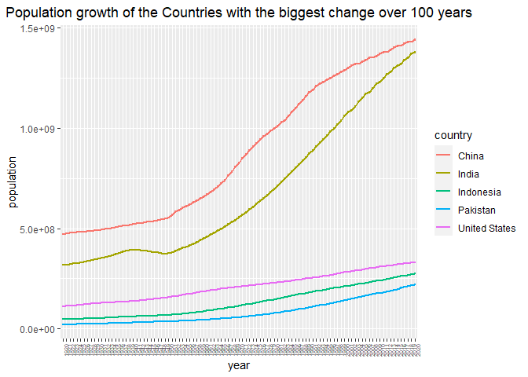

```r
population%>%
  filter(country=="India"|country=="China"|country=="Indonesia"|country=="United States"|country=="Pakistan")%>%
  pivot_longer(-country,
               names_to = "year",
               values_to = "population")%>%
  filter(between(year,1920,2020))%>%
  ggplot(aes(x=year,y=population,color=country))+
  geom_point(size=0.5)+
  geom_line(mapping = aes(group=country),size=1)+
  labs(title = "Population growth of the Countries with the biggest change over 100 years",
       x="year",
       y="population")+
  theme(plot.title = element_text(size = rel(1.2),hjust = 0.5))+
  theme(axis.text.x = element_text(size=5, angle = 90, hjust=1))
```

## Income

Theunits used for income are gross domestic product per person adjusted for differences in purchasing power in international dollars.

```r
income_long
```

```
## # A tibble: 46,513 x 3
##    country     year  income_gdp
##    <chr>       <chr>      <dbl>
##  1 Afghanistan 1800         603
##  2 Afghanistan 1801         603
##  3 Afghanistan 1802         603
##  4 Afghanistan 1803         603
##  5 Afghanistan 1804         603
##  6 Afghanistan 1805         603
##  7 Afghanistan 1806         603
##  8 Afghanistan 1807         603
##  9 Afghanistan 1808         603
## 10 Afghanistan 1809         603
## # ... with 46,503 more rows
```

8. (4 points) As in the previous questions, which countries have experienced the biggest growth in per person GDP. Show this as a table and then plot the changes for the top 5 countries. With a bit of research, you should be able to explain the dramatic downturns of the wealthiest economies that occurred during the 1980’s.  
   #Qatar is the country that have experienced the biggest growth #Qatar’s economy was in a downturn from 1982 to 1989. OPEC (Organization of Petroleum Exporting Countries) quotas on crude oil production, the lower price for oil, and the generally unpromising outlook on international markets reduced oil earnings. In turn, the Qatari government’s spending plans had to be cut to match lower income. The resulting recessionary local business climate caused many firms to lay off expatriate staff.-wikipedia

```r
income_long%>%
  filter(year=="1920"|year=="2020")%>%
  pivot_wider(names_from = year,
              names_prefix = "yr_",
              values_from = income_gdp)%>%
  group_by(country)%>%
  mutate(gap_income_gdp=yr_2020-yr_1920)%>%
  arrange(desc(gap_income_gdp))
```

```
## # A tibble: 193 x 4
## # Groups:   country [193]
##    country              yr_1920 yr_2020 gap_income_gdp
##    <chr>                  <dbl>   <dbl>          <dbl>
##  1 Qatar                   2300  116000         113700
##  2 Luxembourg              5730   95100          89370
##  3 Singapore               2440   90500          88060
##  4 Brunei                  2130   75100          72970
##  5 Ireland                 5170   74100          68930
##  6 United Arab Emirates    2090   65300          63210
##  7 Kuwait                  2350   64300          61950
##  8 Norway                  8960   67500          58540
##  9 Monaco                  6630   62000          55370
## 10 San Marino              3280   57900          54620
## # ... with 183 more rows
```

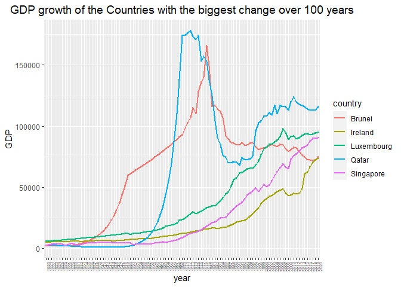

```r
income_gdp%>%
  filter(country=="Qatar"|country=="Luxembourg"|country=="Singapore"|country=="Brunei"|country=="Ireland")%>%
  pivot_longer(-country,
               names_to = "year",
               values_to = "income_gdp")%>%
  filter(between(year,1920,2020))%>%
  ggplot(aes(x=year,y=income_gdp,color=country))+
  geom_point(size=0.5)+
  geom_line(mapping = aes(group=country),size=1)+
  labs(title = "GDP growth of the Countries with the biggest change over 100 years",
       x="year",
       y="GDP")+
  theme(plot.title = element_text(size = rel(1.3),hjust = 0.5))+
  theme(axis.text.x = element_text(size=5, angle = 90, hjust=1))
```

9. (3 points) Create three new objects that restrict each data set (life expectancy, population, income) to the years 1920-2020. Hint: I suggest doing this with the long form of your data. Once this is done, merge all three data sets using the code I provide below. You may need to adjust the code depending on how you have named your objects. I called mine `life_expectancy_100`, `population_100`, and `income_100`. For some of you, learning these `joins` will be important for your project.

```r
income_100<-income_long%>%
  filter(between(year,1920,2020))
```

```r
life_expectancy_100<-life_long%>%
  filter(between(year,1920,2020))
```

```r
population_100<-pop_long%>%
  filter(between(year,1920,2020))
```

```r
gapminder_join <- inner_join(life_expectancy_100, population_100, by= c("country", "year"))
gapminder_join <- inner_join(gapminder_join, income_100, by= c("country", "year"))
gapminder_join
```

```
## # A tibble: 18,887 x 5
##    country     year  life_exp      pop income_gdp
##    <chr>       <chr>    <dbl>    <dbl>      <dbl>
##  1 Afghanistan 1920      30.6 10600000       1490
##  2 Afghanistan 1921      30.7 10500000       1520
##  3 Afghanistan 1922      30.8 10300000       1550
##  4 Afghanistan 1923      30.8  9710000       1570
##  5 Afghanistan 1924      30.9  9200000       1600
##  6 Afghanistan 1925      31    8720000       1630
##  7 Afghanistan 1926      31    8260000       1650
##  8 Afghanistan 1927      31.1  7830000       1680
##  9 Afghanistan 1928      31.1  7420000       1710
## 10 Afghanistan 1929      31.2  7100000       1740
## # ... with 18,877 more rows
```

10. (4 points) Use the joined data to perform an analysis of your choice. The analysis should include a comparison between two or more of the variables `life_expectancy`, `population`, or `income.` #In general, it can be seen that gdp also increased as the population increased

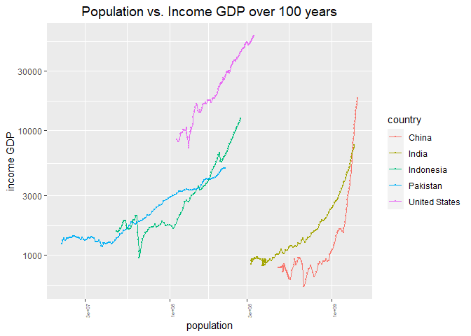

```r
gapminder_join%>%
  filter(country=="India"|country=="China"|country=="Indonesia"|country=="United States"|country=="Pakistan")%>%
  ggplot(aes(x=pop,y=income_gdp,color=country))+
  geom_point(size=0.5,na.rm=T)+
  geom_line(size=0.7)+
  scale_x_log10()+
  scale_y_log10()+
  labs(title = "Population vs. Income GDP over 100 years",
       x="population",
       y="income GDP")+
  theme(plot.title = element_text(size = rel(1.3),hjust = 0.5))+
  theme(axis.text.x = element_text(size=5, angle = 90, hjust=1))
```